# Risk Factor Analysis

## Outcome Variable

**Outcome Variable:** wasted

## Predictor Variables

**Intervention Variable:** single

**Adjustment Set:**

unadjusted

## Stratifying Variables

The analysis was stratified on these variable(s):

- agecat
- studyid
- country

## Data Summary

| agecat | studyid | country | single | wasted | n_cell | n |
| --- | --- | --- | --- | --- | --- | --- |
| Birth | COHORTS | GUATEMALA | 0 | 0 | 486 | 691 |
| Birth | COHORTS | GUATEMALA | 0 | 1 | 168 | 691 |
| Birth | COHORTS | GUATEMALA | 1 | 0 | 29 | 691 |
| Birth | COHORTS | GUATEMALA | 1 | 1 | 8 | 691 |
| Birth | COHORTS | INDIA | 0 | 0 | 3681 | 4463 |
| Birth | COHORTS | INDIA | 0 | 1 | 775 | 4463 |
| Birth | COHORTS | INDIA | 1 | 0 | 6 | 4463 |
| Birth | COHORTS | INDIA | 1 | 1 | 1 | 4463 |
| Birth | COHORTS | PHILIPPINES | 0 | 0 | 2365 | 2860 |
| Birth | COHORTS | PHILIPPINES | 0 | 1 | 424 | 2860 |
| Birth | COHORTS | PHILIPPINES | 1 | 0 | 55 | 2860 |
| Birth | COHORTS | PHILIPPINES | 1 | 1 | 16 | 2860 |
| Birth | JiVitA-4 | BANGLADESH | 0 | 0 | 2150 | 2393 |
| Birth | JiVitA-4 | BANGLADESH | 0 | 1 | 238 | 2393 |
| Birth | JiVitA-4 | BANGLADESH | 1 | 0 | 5 | 2393 |
| Birth | JiVitA-4 | BANGLADESH | 1 | 1 | 0 | 2393 |
| Birth | MAL-ED | BANGLADESH | 0 | 0 | 179 | 215 |
| Birth | MAL-ED | BANGLADESH | 0 | 1 | 36 | 215 |
| Birth | MAL-ED | BANGLADESH | 1 | 0 | 0 | 215 |
| Birth | MAL-ED | BANGLADESH | 1 | 1 | 0 | 215 |
| Birth | MAL-ED | BRAZIL | 0 | 0 | 53 | 62 |
| Birth | MAL-ED | BRAZIL | 0 | 1 | 1 | 62 |
| Birth | MAL-ED | BRAZIL | 1 | 0 | 7 | 62 |
| Birth | MAL-ED | BRAZIL | 1 | 1 | 1 | 62 |
| Birth | MAL-ED | INDIA | 0 | 0 | 40 | 45 |
| Birth | MAL-ED | INDIA | 0 | 1 | 5 | 45 |
| Birth | MAL-ED | INDIA | 1 | 0 | 0 | 45 |
| Birth | MAL-ED | INDIA | 1 | 1 | 0 | 45 |
| Birth | MAL-ED | NEPAL | 0 | 0 | 24 | 26 |
| Birth | MAL-ED | NEPAL | 0 | 1 | 2 | 26 |

[output cut: 138 more lines]

The following strata were considered:

- agecat: 24 months, studyid: COHORTS, country: GUATEMALA
- agecat: 24 months, studyid: COHORTS, country: INDIA
- agecat: 24 months, studyid: COHORTS, country: PHILIPPINES
- agecat: 24 months, studyid: JiVitA-4, country: BANGLADESH
- agecat: 24 months, studyid: MAL-ED, country: BANGLADESH
- agecat: 24 months, studyid: MAL-ED, country: BRAZIL
- agecat: 24 months, studyid: MAL-ED, country: INDIA
- agecat: 24 months, studyid: MAL-ED, country: NEPAL
- agecat: 24 months, studyid: MAL-ED, country: PERU
- agecat: 24 months, studyid: MAL-ED, country: SOUTH AFRICA
- agecat: 24 months, studyid: MAL-ED, country: TANZANIA, UNITED REPUBLIC OF
- agecat: 24 months, studyid: PROBIT, country: BELARUS
- agecat: 24 months, studyid: TanzaniaChild2, country: TANZANIA, UNITED REPUBLIC OF
- agecat: 24 months, studyid: ZVITAMBO, country: ZIMBABWE
- agecat: 6 months, studyid: COHORTS, country: GUATEMALA
- agecat: 6 months, studyid: COHORTS, country: INDIA
- agecat: 6 months, studyid: COHORTS, country: PHILIPPINES
- agecat: 6 months, studyid: Guatemala BSC, country: GUATEMALA
- agecat: 6 months, studyid: JiVitA-4, country: BANGLADESH
- agecat: 6 months, studyid: MAL-ED, country: BANGLADESH
- agecat: 6 months, studyid: MAL-ED, country: BRAZIL
- agecat: 6 months, studyid: MAL-ED, country: INDIA
- agecat: 6 months, studyid: MAL-ED, country: NEPAL
- agecat: 6 months, studyid: MAL-ED, country: PERU
- agecat: 6 months, studyid: MAL-ED, country: SOUTH AFRICA
- agecat: 6 months, studyid: MAL-ED, country: TANZANIA, UNITED REPUBLIC OF
- agecat: 6 months, studyid: PROBIT, country: BELARUS
- agecat: 6 months, studyid: TanzaniaChild2, country: TANZANIA, UNITED REPUBLIC OF
- agecat: 6 months, studyid: ZVITAMBO, country: ZIMBABWE
- agecat: Birth, studyid: COHORTS, country: GUATEMALA
- agecat: Birth, studyid: COHORTS, country: INDIA
- agecat: Birth, studyid: COHORTS, country: PHILIPPINES
- agecat: Birth, studyid: JiVitA-4, country: BANGLADESH
- agecat: Birth, studyid: MAL-ED, country: BANGLADESH
- agecat: Birth, studyid: MAL-ED, country: BRAZIL
- agecat: Birth, studyid: MAL-ED, country: INDIA
- agecat: Birth, studyid: MAL-ED, country: NEPAL
- agecat: Birth, studyid: MAL-ED, country: PERU
- agecat: Birth, studyid: MAL-ED, country: SOUTH AFRICA
- agecat: Birth, studyid: MAL-ED, country: TANZANIA, UNITED REPUBLIC OF
- agecat: Birth, studyid: PROBIT, country: BELARUS
- agecat: Birth, studyid: ZVITAMBO, country: ZIMBABWE

### Dropped Strata

Some strata were dropped due to rare outcomes:

- agecat: Birth, studyid: COHORTS, country: INDIA
- agecat: Birth, studyid: JiVitA-4, country: BANGLADESH
- agecat: Birth, studyid: MAL-ED, country: BANGLADESH
- agecat: Birth, studyid: MAL-ED, country: BRAZIL
- agecat: Birth, studyid: MAL-ED, country: INDIA
- agecat: Birth, studyid: MAL-ED, country: NEPAL
- agecat: Birth, studyid: MAL-ED, country: PERU
- agecat: Birth, studyid: MAL-ED, country: TANZANIA, UNITED REPUBLIC OF
- agecat: 6 months, studyid: COHORTS, country: GUATEMALA
- agecat: 6 months, studyid: COHORTS, country: INDIA
- agecat: 6 months, studyid: Guatemala BSC, country: GUATEMALA
- agecat: 6 months, studyid: JiVitA-4, country: BANGLADESH
- agecat: 6 months, studyid: MAL-ED, country: BANGLADESH
- agecat: 6 months, studyid: MAL-ED, country: BRAZIL
- agecat: 6 months, studyid: MAL-ED, country: INDIA
- agecat: 6 months, studyid: MAL-ED, country: NEPAL
- agecat: 6 months, studyid: MAL-ED, country: PERU
- agecat: 6 months, studyid: MAL-ED, country: SOUTH AFRICA
- agecat: 6 months, studyid: MAL-ED, country: TANZANIA, UNITED REPUBLIC OF
- agecat: 6 months, studyid: PROBIT, country: BELARUS
- agecat: 24 months, studyid: COHORTS, country: INDIA
- agecat: 24 months, studyid: JiVitA-4, country: BANGLADESH
- agecat: 24 months, studyid: MAL-ED, country: BANGLADESH
- agecat: 24 months, studyid: MAL-ED, country: BRAZIL
- agecat: 24 months, studyid: MAL-ED, country: INDIA
- agecat: 24 months, studyid: MAL-ED, country: NEPAL
- agecat: 24 months, studyid: MAL-ED, country: PERU
- agecat: 24 months, studyid: MAL-ED, country: SOUTH AFRICA
- agecat: 24 months, studyid: MAL-ED, country: TANZANIA, UNITED REPUBLIC OF
- agecat: 24 months, studyid: PROBIT, country: BELARUS
- agecat: 24 months, studyid: TanzaniaChild2, country: TANZANIA, UNITED REPUBLIC OF
- agecat: 24 months, studyid: ZVITAMBO, country: ZIMBABWE

## Methods Detail

We’re interested in the causal parameters $E[Y_a]$ for all values of $a \in \mathcal{A}$. These parameters represent the mean outcome if, possibly contrary to fact, we intervened to set all units to have $A=a$. Under the randomization and positivity assumptions, these are identified by the statistical parameters $\psi_a=E_W[E_{Y|A,W}(Y|A=a,W)]$. In addition, we’re interested in the mean of $Y$, $E[Y]$ under no intervention (the observed mean). We will estimate these parameters by using SuperLearner to fit the relevant likelihood factors – $E_{Y|A,W}(Y|A=a,W)$ and $p(A=a|W)$, and then updating our likelihood fit using a joint TMLE.

For unadjusted analyses ($W=\{\}$), initial likelihoods were estimated using Lrnr_glm to estimate the simple $E(Y|A)$ and Lrnr_mean to estimate $p(A)$. For adjusted analyses, a small library containing Lrnr_glmnet, Lrnr_xgboost, and Lrnr_mean was used.

Having estimated these parameters, we will then use the delta method to estimate relative risks and attributable risks relative to a prespecified baseline level of $A$.

# Results Detail

## Results Plots

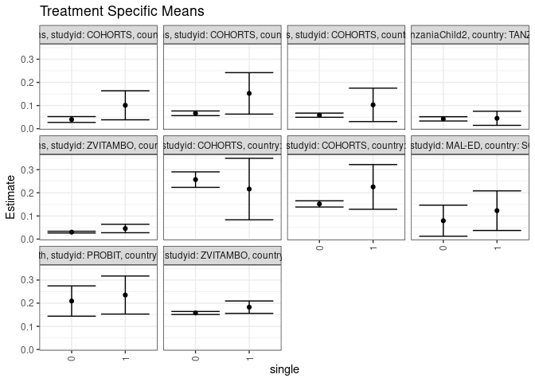

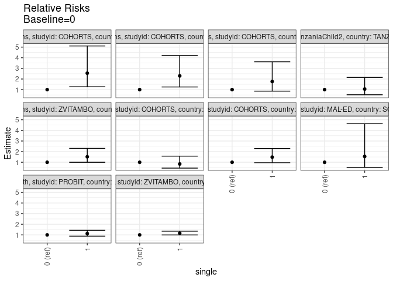

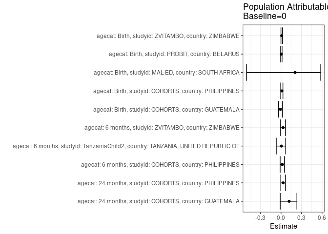

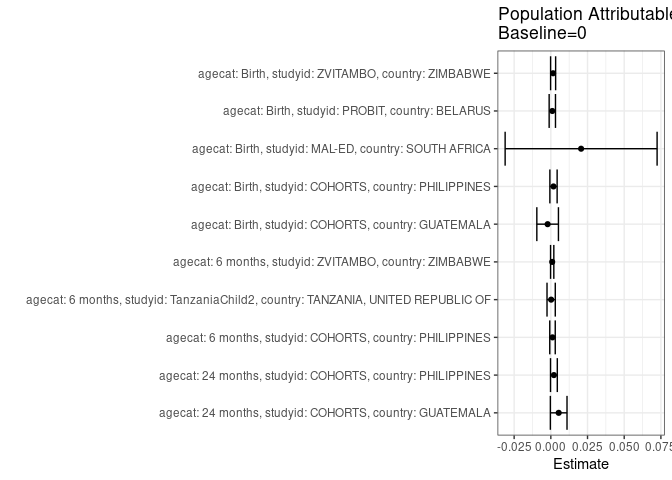

## Results Table

### Parameter: TSM

| agecat | studyid | country | intervention_level | baseline_level | estimate | ci_lower | ci_upper |
| --- | --- | --- | --- | --- | --- | --- | --- |
| Birth | COHORTS | GUATEMALA | 0 | NA | 0.2568807 | 0.2233712 | 0.2903903 |
| Birth | COHORTS | GUATEMALA | 1 | NA | 0.2162162 | 0.0834756 | 0.3489569 |
| Birth | COHORTS | PHILIPPINES | 0 | NA | 0.1520258 | 0.1386959 | 0.1653557 |
| Birth | COHORTS | PHILIPPINES | 1 | NA | 0.2253521 | 0.1288293 | 0.3218750 |
| Birth | MAL-ED | SOUTH AFRICA | 0 | NA | 0.0793651 | 0.0123375 | 0.1463926 |
| Birth | MAL-ED | SOUTH AFRICA | 1 | NA | 0.1228070 | 0.0372438 | 0.2083702 |
| Birth | PROBIT | BELARUS | 0 | NA | 0.2093093 | 0.1438982 | 0.2747204 |
| Birth | PROBIT | BELARUS | 1 | NA | 0.2351852 | 0.1530948 | 0.3172755 |
| Birth | ZVITAMBO | ZIMBABWE | 0 | NA | 0.1577290 | 0.1512249 | 0.1642330 |
| Birth | ZVITAMBO | ZIMBABWE | 1 | NA | 0.1827284 | 0.1559319 | 0.2095249 |
| 6 months | COHORTS | PHILIPPINES | 0 | NA | 0.0583269 | 0.0493273 | 0.0673266 |
| 6 months | COHORTS | PHILIPPINES | 1 | NA | 0.1029412 | 0.0307008 | 0.1751815 |
| 6 months | TanzaniaChild2 | TANZANIA, UNITED REPUBLIC OF | 0 | NA | 0.0425300 | 0.0332922 | 0.0517677 |
| 6 months | TanzaniaChild2 | TANZANIA, UNITED REPUBLIC OF | 1 | NA | 0.0449438 | 0.0145003 | 0.0753874 |
| 6 months | ZVITAMBO | ZIMBABWE | 0 | NA | 0.0301091 | 0.0263574 | 0.0338608 |
| 6 months | ZVITAMBO | ZIMBABWE | 1 | NA | 0.0457256 | 0.0274696 | 0.0639817 |
| 24 months | COHORTS | GUATEMALA | 0 | NA | 0.0396996 | 0.0271581 | 0.0522411 |
| 24 months | COHORTS | GUATEMALA | 1 | NA | 0.1011236 | 0.0384561 | 0.1637911 |
| 24 months | COHORTS | PHILIPPINES | 0 | NA | 0.0664972 | 0.0564389 | 0.0765556 |
| 24 months | COHORTS | PHILIPPINES | 1 | NA | 0.1525424 | 0.0630548 | 0.2420299 |

### Parameter: E(Y)

| agecat | studyid | country | intervention_level | baseline_level | estimate | ci_lower | ci_upper |
| --- | --- | --- | --- | --- | --- | --- | --- |
| Birth | COHORTS | GUATEMALA | NA | NA | 0.2547033 | 0.2221942 | 0.2872125 |
| Birth | COHORTS | PHILIPPINES | NA | NA | 0.1538462 | 0.1406207 | 0.1670716 |
| Birth | MAL-ED | SOUTH AFRICA | NA | NA | 0.1000000 | 0.0460991 | 0.1539009 |
| Birth | PROBIT | BELARUS | NA | NA | 0.2103206 | 0.1450833 | 0.2755580 |
| Birth | ZVITAMBO | ZIMBABWE | NA | NA | 0.1592817 | 0.1529578 | 0.1656056 |
| 6 months | COHORTS | PHILIPPINES | NA | NA | 0.0594615 | 0.0504964 | 0.0684266 |
| 6 months | TanzaniaChild2 | TANZANIA, UNITED REPUBLIC OF | NA | NA | 0.0427435 | 0.0339027 | 0.0515843 |
| 6 months | ZVITAMBO | ZIMBABWE | NA | NA | 0.0310361 | 0.0273436 | 0.0347286 |
| 24 months | COHORTS | GUATEMALA | NA | NA | 0.0450539 | 0.0323246 | 0.0577831 |
| 24 months | COHORTS | PHILIPPINES | NA | NA | 0.0685950 | 0.0585223 | 0.0786677 |

### Parameter: RR

| agecat | studyid | country | intervention_level | baseline_level | estimate | ci_lower | ci_upper |
| --- | --- | --- | --- | --- | --- | --- | --- |
| Birth | COHORTS | GUATEMALA | 0 | 0 | 1.0000000 | 1.0000000 | 1.000000 |
| Birth | COHORTS | GUATEMALA | 1 | 0 | 0.8416988 | 0.4493449 | 1.576644 |
| Birth | COHORTS | PHILIPPINES | 0 | 0 | 1.0000000 | 1.0000000 | 1.000000 |
| Birth | COHORTS | PHILIPPINES | 1 | 0 | 1.4823279 | 0.9573473 | 2.295192 |
| Birth | MAL-ED | SOUTH AFRICA | 0 | 0 | 1.0000000 | 1.0000000 | 1.000000 |
| Birth | MAL-ED | SOUTH AFRICA | 1 | 0 | 1.5473684 | 0.5177350 | 4.624662 |
| Birth | PROBIT | BELARUS | 0 | 0 | 1.0000000 | 1.0000000 | 1.000000 |
| Birth | PROBIT | BELARUS | 1 | 0 | 1.1236249 | 0.8811413 | 1.432838 |
| Birth | ZVITAMBO | ZIMBABWE | 0 | 0 | 1.0000000 | 1.0000000 | 1.000000 |
| Birth | ZVITAMBO | ZIMBABWE | 1 | 0 | 1.1584962 | 0.9948026 | 1.349125 |
| 6 months | COHORTS | PHILIPPINES | 0 | 0 | 1.0000000 | 1.0000000 | 1.000000 |
| 6 months | COHORTS | PHILIPPINES | 1 | 0 | 1.7648994 | 0.8603360 | 3.620527 |
| 6 months | TanzaniaChild2 | TANZANIA, UNITED REPUBLIC OF | 0 | 0 | 1.0000000 | 1.0000000 | 1.000000 |
| 6 months | TanzaniaChild2 | TANZANIA, UNITED REPUBLIC OF | 1 | 0 | 1.0567560 | 0.5188512 | 2.152319 |
| 6 months | ZVITAMBO | ZIMBABWE | 0 | 0 | 1.0000000 | 1.0000000 | 1.000000 |
| 6 months | ZVITAMBO | ZIMBABWE | 1 | 0 | 1.5186630 | 0.9995869 | 2.307291 |
| 24 months | COHORTS | GUATEMALA | 0 | 0 | 1.0000000 | 1.0000000 | 1.000000 |
| 24 months | COHORTS | GUATEMALA | 1 | 0 | 2.5472214 | 1.2705067 | 5.106889 |
| 24 months | COHORTS | PHILIPPINES | 0 | 0 | 1.0000000 | 1.0000000 | 1.000000 |
| 24 months | COHORTS | PHILIPPINES | 1 | 0 | 2.2939652 | 1.2516399 | 4.204306 |

### Parameter: PAR

| agecat | studyid | country | intervention_level | baseline_level | estimate | ci_lower | ci_upper |
| --- | --- | --- | --- | --- | --- | --- | --- |
| Birth | COHORTS | GUATEMALA | 0 | NA | -0.0021774 | -0.0095398 | 0.0051850 |
| Birth | COHORTS | PHILIPPINES | 0 | NA | 0.0018203 | -0.0006513 | 0.0042919 |
| Birth | MAL-ED | SOUTH AFRICA | 0 | NA | 0.0206349 | -0.0311403 | 0.0724101 |
| Birth | PROBIT | BELARUS | 0 | NA | 0.0010113 | -0.0011473 | 0.0031699 |
| Birth | ZVITAMBO | ZIMBABWE | 0 | NA | 0.0015527 | -0.0001631 | 0.0032686 |
| 6 months | COHORTS | PHILIPPINES | 0 | NA | 0.0011345 | -0.0007358 | 0.0030049 |
| 6 months | TanzaniaChild2 | TANZANIA, UNITED REPUBLIC OF | 0 | NA | 0.0002135 | -0.0026012 | 0.0030283 |
| 6 months | ZVITAMBO | ZIMBABWE | 0 | NA | 0.0009270 | -0.0001821 | 0.0020360 |
| 24 months | COHORTS | GUATEMALA | 0 | NA | 0.0053543 | -0.0003173 | 0.0110259 |
| 24 months | COHORTS | PHILIPPINES | 0 | NA | 0.0020978 | -0.0002148 | 0.0044103 |

### Parameter: PAF

| agecat | studyid | country | intervention_level | baseline_level | estimate | ci_lower | ci_upper |
| --- | --- | --- | --- | --- | --- | --- | --- |
| Birth | COHORTS | GUATEMALA | 0 | NA | -0.0085488 | -0.0378663 | 0.0199405 |
| Birth | COHORTS | PHILIPPINES | 0 | NA | 0.0118322 | -0.0043446 | 0.0277484 |
| Birth | MAL-ED | SOUTH AFRICA | 0 | NA | 0.2063492 | -0.5049168 | 0.5814509 |
| Birth | PROBIT | BELARUS | 0 | NA | 0.0048083 | -0.0057122 | 0.0152187 |
| Birth | ZVITAMBO | ZIMBABWE | 0 | NA | 0.0097484 | -0.0010785 | 0.0204583 |
| 6 months | COHORTS | PHILIPPINES | 0 | NA | 0.0190803 | -0.0127647 | 0.0499240 |
| 6 months | TanzaniaChild2 | TANZANIA, UNITED REPUBLIC OF | 0 | NA | 0.0049961 | -0.0630759 | 0.0687092 |
| 6 months | ZVITAMBO | ZIMBABWE | 0 | NA | 0.0298673 | -0.0063617 | 0.0647920 |
| 24 months | COHORTS | GUATEMALA | 0 | NA | 0.1188421 | -0.0116736 | 0.2325200 |
| 24 months | COHORTS | PHILIPPINES | 0 | NA | 0.0305823 | -0.0034701 | 0.0634791 |